# Election Results Modeling Analysis

Louis Quicksell

January 7, 2018

## gbm Model - Predicting Trump Counties

In this markdown document, I will walkthrough how I classified counties that Trump won in the 2016 General Election using machine learning techniques, specifically a gradient boosted model or `gbm`. This model will attempt to classify a binary outcome: Trump winning a county or Clinton winning a county. As such, I will need a classification model. I worked through several different models, including a `random forest`, `glm`, and a `glmnet` model before settling on a `gbm` model. Gradient boosting models produce an ensemble of weak prediction models which work in concert to form a single, potent predictive model.

### Data

For this modeling analysis I used two main datasets: one containing the data used to predict the outcome of the election and another containing the actual outcome. To train the model, I used a dataset containing a number of demographic datapoints on counties from the US census. This dataset can be found on Kaggle under the heading: [“2016 US Election”](https://www.kaggle.com/benhamner/2016-us-election/data). The other dataset I used contained vote counts from the 2016 General election for President by county. This dataset was pulled from [the New York Times](http://www.nytimes.com/elections/results/president) and can be found on Github [here](https://github.com/Deleetdk/USA.county.data). The data I used to predict the election outcome included:

```
##  [1] "Population, 2014 estimate"
##  [2] "Population, 2010 (April 1) estimates base"
##  [3] "Population, percent change - April 1, 2010 to July 1, 2014"
##  [4] "Population, 2010"
##  [5] "Persons under 5 years, percent, 2014"
##  [6] "Persons under 18 years, percent, 2014"
##  [7] "Persons 65 years and over, percent, 2014"
##  [8] "Female persons, percent, 2014"
##  [9] "White alone, percent, 2014"
## [10] "Black or African American alone, percent, 2014"
## [11] "American Indian and Alaska Native alone, percent, 2014"
## [12] "Asian alone, percent, 2014"
## [13] "Native Hawaiian and Other Pacific Islander alone, percent, 2014"
## [14] "Two or More Races, percent, 2014"
## [15] "Hispanic or Latino, percent, 2014"
```

[output cut: 36 more lines]

### Variable Selection

A key challenge to selecting the best subset of predictors for the model is balancing the overall predictiveness with model simplicity. An optimal model is one that explains the data in the simplest way that is still highly predictive. Eliminating uneccesary predictors removes noise from the estimation of other quantities, reduces the cost of the model model and limits the possibility of collinearity. In this case, I chose to include the whole dataset of county facts to maximize the predictiveness of the model.

### Data Cleaning and Merging

I first needed to clean and merge the two datasets so they can be used in the model. To merge the datasets, both need to have an ID variable that can be used to match county facts to the election results from that county. The Census FIPS code is a perfect ID variable for this, since there is a FIPS code for each US state and county. The US Census Bureau provides a file containing the FIPS codes [here](https://www.census.gov/geo/reference/codes/cou.html). The election results dataset already had a FIPS code variable; however, the county facts dataset did not, so first I needed to append it.

```r
#Coerce State fips code to integer (to be consistent with election results dataset)
fips_codes$State_FP_2 <- as.integer(fips_codes$State_FP)
#Concatenate state and county fips code
fips_codes$FPCODE <- as.integer(paste(fips_codes$State_FP_2, fips_codes$County_FP, sep = ""))
#Join fips code dataset to county facts dataset
county_facts_fips <- right_join(county_facts_1, fips_codes, by = c("fips" = "FPCODE"))
```

Next, I selected the pertinent data points from the elections data set and merged it with the county facts dataset using the FIPS code as the common ID.

```r
#Select Trump and Clinton vote counts as well as overall vote counts and fips code
results_2016_pres <- USA_county_data %>% dplyr::select(fips, name_16, votes, votes16_trumpd, votes16_clintonh)
#Merge county facts and election results datasets
county_results_facts <- right_join(results_2016_pres, county_facts_fips, by = "fips")
```

With the two datasets merged, I needed to create a factor variable which containing who had won the county, which the model will use as the dependent variable.

```r
#If Trump had more votes than Clinton, TrumpCounty, if not NotTrumpCounty
county_results_facts$TrumpCounty <- as.factor(ifelse(county_results_facts$votes16_clintonh > county_results_facts$votes16_trumpd, "NotTrumpCounty", "TrumpCounty"))
```

The election results dataset did not include data for Alaska and a few other counties where the county had changed names since the election. Thus I had to remove counties which did not have data on the 2016 election.

```r
#Select rows where election results are not missing
county_results <- county_results_facts[!is.na(county_results_facts$TrumpCounty),]
```

### Partition Data

With the datasets cleaned and merged, I needed to partition the data into a training and a test set. As the title suggests, the training dataset is used to train the model and the test dataset to test the model. First, I needed to trim down the dataset to include only those variables that were used by the model.

```r
#Set random seed so results are reproducible
set.seed(8765)

#Model dataset
modMergedARV <- county_results %>% dplyr::select(PST045214:POP060210, TrumpCounty)
```

It is very important to set the random number generator to an integer. This allows my results to be reproducible in the future. I used 30% of the original dataset as the training dataset for a 30/70 training/test split.

```r
#Models created with 30% sample
inTrain <- createDataPartition(y=modMergedARV$TrumpCounty, p=0.3, list=FALSE)
#Training dataset
training <- modMergedARV[inTrain,]
#Test dataset
testing <- modMergedARV[-inTrain,]
```

### Model Tuning and Creation

Next, I needed to pre-process the data so that it is ready to be fed into our model. To deal with any missing values in the data I used median imputation. This method replaces missing values in a variable with the median value of the variable and is best used when data is missing-at-random. Within the same pre-processing statement, I centered (subtract the mean of each column from each value in that column) and scaled (divide the standard deviation of each column from each value in that column) the data. The `predict` function applies the pre-process object onto the training/test sets.

```r
#Create pre-process object, specifying the pre-processing methods
preProcValues <- preProcess(train1, method = c("medianImpute","center", "scale"))
#Create pre-processed training dataset
trainTrans <- predict(preProcValues, train1)
#Create pre-processed test dataset
testTrans <- predict(preProcValues, test1)
```

With the training and test datasets pre-processed, I needed to create the `trainControl` object that dictates how the model was trained

```r
objControl <- trainControl(method = "repeatedcv",
                           number = 5,
                           repeats = 1,
                           classProbs = TRUE,
                           summaryFunction = twoClassSummary)
```

For this `trainControl` object, I specified that the model was to perform 5-fold cross validation, repeated once to determine the optimal values for tuning parameters of the model. Since this is a classification model, I also specified that class probabilities should be computed and that the `twoClassSummary` method should be used to compute the performance of the model across resamples.

With that, I ran the model.

```r
fit.gbm <- train(TrumpCounty ~ .,
                 data = trainTransformed,
                 method = "gbm",
                 tuneLength = 10,
                 trControl = objControl,
                 metric = "ROC"
)
```

The actual train statement pulls in all of the data and various model objects we have prepared and trains the model to predict the given outcome: Trump winning a county. I specify that that the area under the ROC curve should be used as the metric to select the optimal model. The ROC method is ideal for this model as it evaluates the diagnostic ability of a binary classifier system over diferent discrimination thresholds. Essentially, it is a method for determining the accuracy of model predictions.

### Evaluating Model Performance

With the model created, I used both the test and training datasets to see how well it performed. First, I needed to predict on the test data using the model object.

```r
testpred.gbm <- predict(fit.gbm, testTransformed, type="prob")
```

I used a histogram to see the distribution of predicted Trump counties.

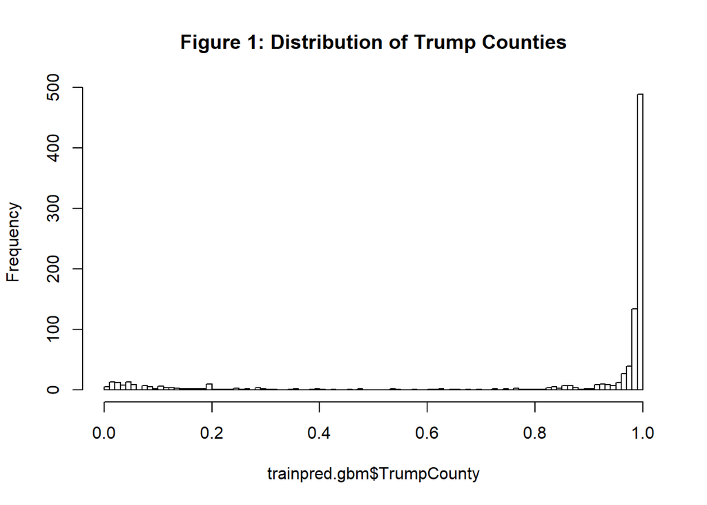

```r
hist(trainpred.gbm$TrumpCounty, breaks = 100, main = "Figure 1: Distribution of Trump Counties")
```

The majority of observations were on the higher end of the scale, meaning the majority of observations were predicted to be Trump counties. That is a good result, given that (Trump won 2,626 of 3,141 counties in the US)[http://www.dispatch.com/content/stories/national_world/2016/12/06/1206-clinton-won-487-counties.html]. The distribution of predicted Trump counties against the actual Trump counties also indicates that the model was accurate in its predictions.

```r
test_cut_table <- prop.table(table(testTransformed$TrumpCounty,cut(testpred.gbm[,2], c(0,.1,.2,.3,.4,.5,.6,.7,.8,.9,1))),2)
kable(test_cut_table, caption = "Table 1: Distribution of Actual by Predicted Trump Counties")
```

Table 1: Distribution of Actual by Predicted Trump Counties

|  | (0,0.1] | (0.1,0.2] | (0.2,0.3] | (0.3,0.4] | (0.4,0.5] | (0.5,0.6] | (0.6,0.7] | (0.7,0.8] | (0.8,0.9] | (0.9,1] |
| --- | --- | --- | --- | --- | --- | --- | --- | --- | --- | --- |
| NotTrumpCounty | 0.966443 | 0.8507463 | 0.6976744 | 0.5714286 | 0.4615385 | 0.4516129 | 0.3023256 | 0.3414634 | 0.1136364 | 0.0157195 |
| TrumpCounty | 0.033557 | 0.1492537 | 0.3023256 | 0.4285714 | 0.5384615 | 0.5483871 | 0.6976744 | 0.6585366 | 0.8863636 | 0.9842805 |

Table 1 shows the proportion of counties Trump actually won by predicted Trump county scores, cut by value on predicted Trump county scores into 10 different subsets. If the model is accurately predicting Trump counties, each subset’s range of predicted Trump county scores would be mirrored by the distribution of counties Trump actually won within that subset. Thus, the first subset which displays the distribution of actual Trump counties where the predicted Trump county score ranged from (0,.1], the very low range of Trump county scores would ideally correspond with a low proportion of actual Trump counties, or a very high percentage of Not Trump counties (Clinton counties). As the range of predicted Trump county scores increases, a corresponding increase in the number of counties Trump actually won should occur. This trend is clearly illustrated by the proportions shown in Table 1. The middle subsets do no bear out this trend as clearly (as is expected given that the model is predicting a binary outcome). The distribution of actual Trump counties within the two subsets (0.4,0.5] and (0.5,0.6] is essentially the same. Ideally, the distributions of counties Trump actually won within these subsets would fall along the lines of a 50/50 split. However, this is some serious nitpicking and the overall distribution of actual by predicted Trump counties looks very good.

The accuracy of the model can be more succintly shown by plotting the ROC curve calculated from the model. An ROC curve is a plot of a model’s true positive rate against its false positive rate at every possible cut-off threshold. The accuracy of the model is measured by the area under the ROC curve (AUC). The area measures discrimination, or the ability of a model to correctly classify counties which Trump won or lost. AUC ranges from 0 to 1, where an AUC of 0 represents a model that always predicts the incorrect outcome and an AUC of 1 represents a model that always predicts the correct outcome.

```r
ROC.gbm <- roc(testTransformed$TrumpCounty,testpred.gbm[,2])
ROC.gbm
```

```
##
## Call:
## roc.default(response = testTransformed$TrumpCounty, predictor = testpred.gbm[,     2])
##
## Data: testpred.gbm[, 2] in 340 controls (testTransformed$TrumpCounty NotTrumpCounty) < 1837 cases (testTransformed$TrumpCounty TrumpCounty).
## Area under the curve: 0.9685
```

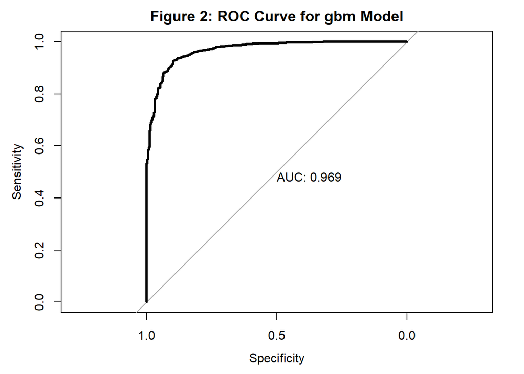

```r
plot.roc(ROC.gbm, lwd=3, main = "Figure 2: ROC Curve for gbm Model", print.auc = TRUE)
```

Figure 2 displays the ROC curve of the model. The closer the curve follows the y-axis or the left hand border and then the top border of the ROC space, the more area is captured under the curve and the more accurate the model. The model was extremely accurate, with a AUC of 0.97. The **caret** function `varImp` shows which variables were most important to the model’s performance.

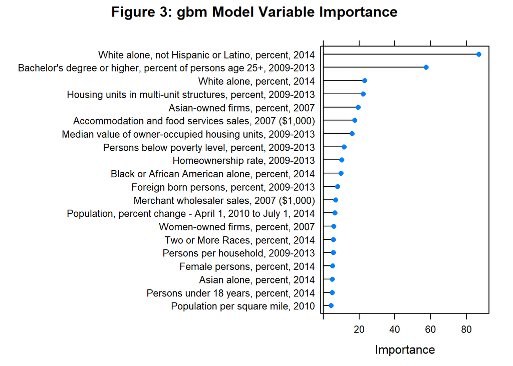

```r
imp <- varImp(fit.gbm, scale = F)
imp$importance$column_name <- row.names(df_imp)
imp$importance <- merge(facts_dict, imp$importance, by = "column_name")
row.names(imp$importance) <- imp$importance$description
imp$importance <- select(imp$importance, -column_name, -description)
plot(imp, top = 20, main = "Figure 3: gbm Model Variable Importance ")
```